# Swiftkey Text Mining and Analytics Project - Milestone Report

Kevin Roche

24/11/2021

# Overview

This report serves to provide a summary of the preliminary analysis I’ve done on my Swiftkey text mining and analytics project.

The goal of the project is to develop a shiny application that can be used to predict the next word in a string of text. So far, the project is made up of three scripts:

The code for these scripts is displayed in the appendix.

# Summary Stats

Before I begin manipulating the data into corpus format, let’s take a quick look at the summary statistics. Here I’ve calculated:

- The number of lines in each file.
- The number of characters in each file.
- The size of each file.

Summary Stats

| file | Number of lines | Number of characters | File size |
| --- | --- | --- | --- |
| blogs | 899288 | 206824382 | 210.16 mb |
| news | 1010242 | 203223154 | 205.81 mb |
| twitter | 2360148 | 162096031 | 167.11 mb |

# Data Processing

## Raw Data

1.5m words makes for a more than sufficient sample size, and still allows for a reasonable performance time when modeling. The raw data (written to the *dataSamples* folder so that it can be presented here) looks like this:

Raw Data Sample

| blogs | news | twitter |
| --- | --- | --- |
| so anyways, i am going to share some home decor inspiration that i have been storing in my folder on the puter. i have all these amazing images stored away ready to come to life when we get our home. | The Alaimo Group of Mount Holly was up for a contract last fall to evaluate and suggest improvements to Trenton Water Works. But campaign finance records released this week show the two employees dona… | So Tired D; Played Lazer Tag & Ran A LOT D; Ughh Going To Sleep Like In 5 Minutes ;) |
| With graduation season right around the corner, Nancy has whipped up a fun set to help you out with not only your graduation cards and gifts, but any occasion that brings on a change in one’s life. I … | And when it’s often difficult to predict a law’s impact, legislators should think twice before carrying any bill. Is it absolutely necessary? Is it an issue serious enough to merit their attention? Wi… | Words from a complete stranger! Made my birthday even better :) |
| If you have an alternative argument, let’s hear it! :) | There was a certain amount of scoffing going around a few years ago when the NFL decided to move the draft from the weekend to prime time – eventually splitting off the first round to a separate day. | First Cubs game ever! Wrigley field is gorgeous. This is perfect. Go Cubs Go! |

## Data for EDA

To prepare the data for Exploratory Data Analysis (EDA), I made the following manipulations:

- Data was converted to VCorpus format using the `tm` package. Corpus’ represent a collection of texts, with VCorpus (short for *volatile corpus*) denoting that the texts are held entirely in memory.
- Numbers, punctuation, and whitespace were removed from the corpus.
- All words were transformed to lowercase so that the program recognizes (for example) “hello” and “Hello” as the same word.
- The texts in the corpus were tokenized, meaning that the text was broken into one-row-per-word tokens.
- Stopwords (commonly used words that convey little information - think “the”, “a”, etc.) were removed, sourcing the widely-used “snowball” list of stopwords.
- Word stems were computed using the `SnowballC` package.
- Bigrams, trigrams, fourgrams and fivegrams were computed using R’s `lead` and `lag` functions. If an n-gram wasn’t complete (for example, if there wasn’t five words in a sentence), the corresponding n-gram was replaced with NA.

Once the above changes are made, the data (written to the *tidyData* folder) looks like this:

Tidy Data Sample

| author | datetimestamp | description | heading | id | language | origin | word | stem | bigram | trigram | fourgram | fivegram | dataset |
| --- | --- | --- | --- | --- | --- | --- | --- | --- | --- | --- | --- | --- | --- |
| NA | 2021-11-24 23:09:04 | NA | NA | 1 | en | NA | anyways | anywai | NA | NA | NA | NA | blogs |
| NA | 2021-11-24 23:09:04 | NA | NA | 1 | en | NA | going | go | anyways going | anyways going share | NA | NA | blogs |
| NA | 2021-11-24 23:09:04 | NA | NA | 1 | en | NA | share | share | going share | going share home | anyways going share home | anyways going share home decor | blogs |
| NA | 2021-11-24 23:09:04 | NA | NA | 1 | en | NA | home | home | share home | share home decor | going share home decor | going share home decor inspiration | blogs |
| NA | 2021-11-24 23:09:04 | NA | NA | 1 | en | NA | decor | decor | home decor | home decor inspiration | share home decor inspiration | share home decor inspiration storing | blogs |
| NA | 2021-11-24 23:09:04 | NA | NA | 1 | en | NA | inspiration | inspir | decor inspiration | decor inspiration storing | home decor inspiration storing | home decor inspiration storing folder | blogs |
| NA | 2021-11-24 23:09:04 | NA | NA | 1 | en | NA | storing | store | inspiration storing | inspiration storing folder | decor inspiration storing folder | decor inspiration storing folder puter | blogs |
| NA | 2021-11-24 23:09:04 | NA | NA | 1 | en | NA | folder | folder | storing folder | storing folder puter | inspiration storing folder puter | inspiration storing folder puter amazing | blogs |
| NA | 2021-11-24 23:09:04 | NA | NA | 1 | en | NA | puter | puter | folder puter | folder puter amazing | storing folder puter amazing | storing folder puter amazing images | blogs |
| NA | 2021-11-24 23:09:04 | NA | NA | 1 | en | NA | amazing | amaz | puter amazing | puter amazing images | folder puter amazing images | folder puter amazing images stored | blogs |

## Data for SBO Model

To prepare the data for the Stupid Back-Off (SBO) model, I take a different approach to preparing it:

- First, I use `pivot_longer` to manipulate the data into a dataframe where each row corresponds to a line from one of the three data sources.
- The data is then split into training and testing data. 80% of the data is used in the training set (72k observations), while 20% of the data is used in the testing set (18k observations).
- The data is then converted to corpus format, such that each observation is transformed into its own document.

A different approach is required because the cleaning parameters and tokenization are specified in the actual SBO model. At that stage, I apply the same cleaning and tokenization transformations that were applied in the Data for EDA section. Both the training and testing data are written to the *tidyData* folder.

The training data looks like this:

Training Data Sample

|  | Text |
| --- | --- |
| text1 | ANYONE KNOW HOW TO stop a dog from shedding |
| text2 | I’m talking tonight at 930 on I can only assume they’re doing a “World Series Preview” show. |
| text3 | Then people start dying. A pit-and-pendulum murder here, a victim possibly walled up in a sewer there. A detective (Luke Evans, in a bland performance) figures out that somebody is imitating the death… |

# Exploratory Data Analysis (EDA)

In this section, I compute wordclouds, n-gram frequency plots, TF-IDF frequency plots, and perform sentiment analysis.

## Wordclouds

Here I’ve included a sample of the wordclouds I’ve plotted. I separated the wordclouds by data source to highlight the difference in language each of the three data sources use.

### Example: Unigram Wordcloud - Blogs

Unigram wordclouds don’t tell too much of a story - they’re most filled with common words.

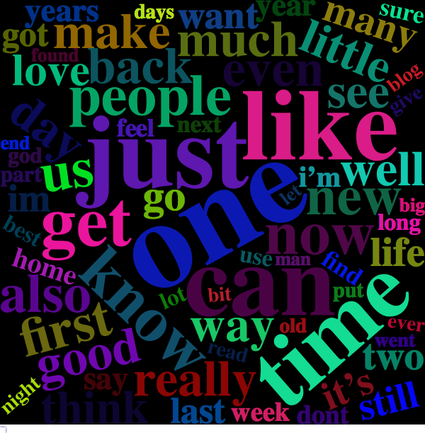

### Example: Bigram Wordcloud - News

Bigram wordclouds tend to be a bit more unique. Here we’re starting to see parts of phrases that you’d expect to see in the news.

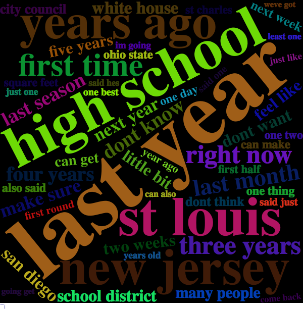

### Example: Trigram Wordcloud - Twitter

Here we can see the trigram wordcloud for the twitter data set. After trigrams, the wordclouds become more sparse, so I haven’t included them in this report.

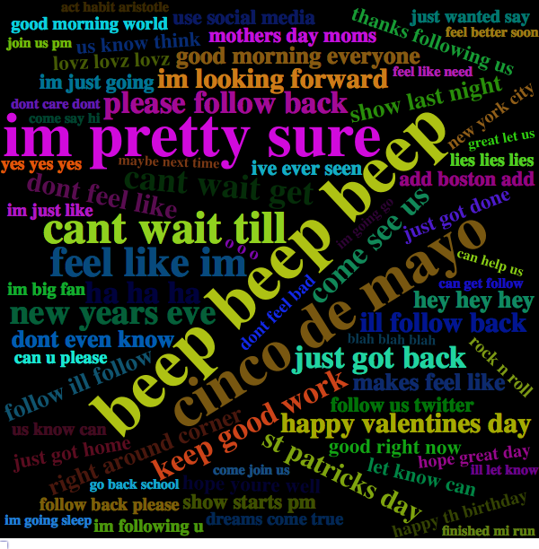

## N-Gram Frequency Plots

In this section I’ve included a sample of the n-gram frequency charts I’ve plotted. Again, I’ve separated the plots by data source to highlight the difference in language that each of the three data sources use. Frequency is calculated as the percentage of the total words the n-gram makes up in the data source.

### Example: Bigram Frequency - Twitter

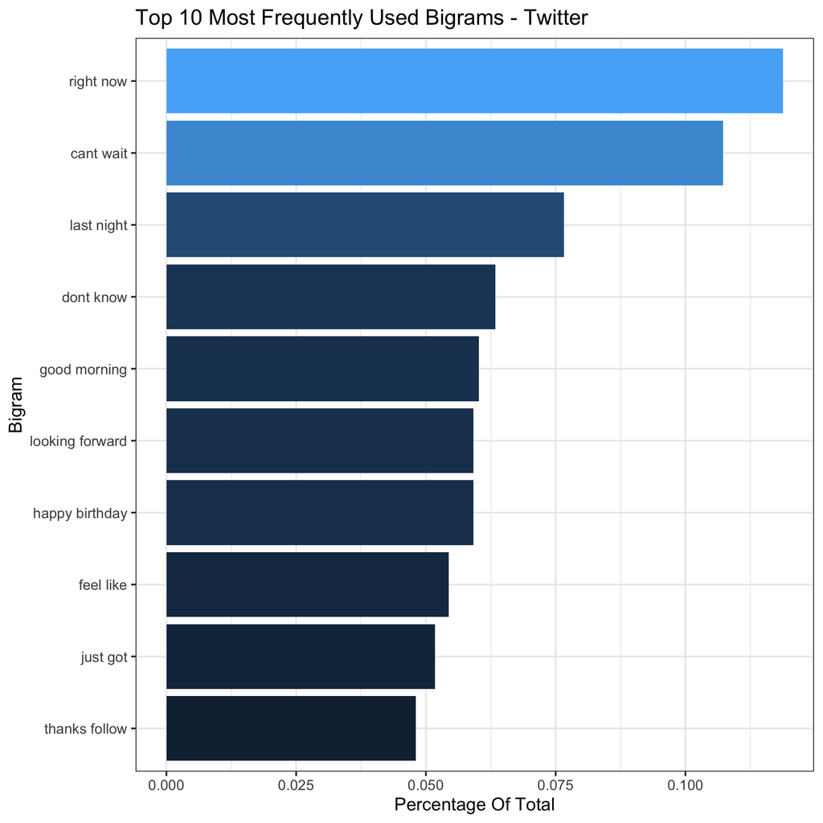

### Example: Trigram Frequency - News

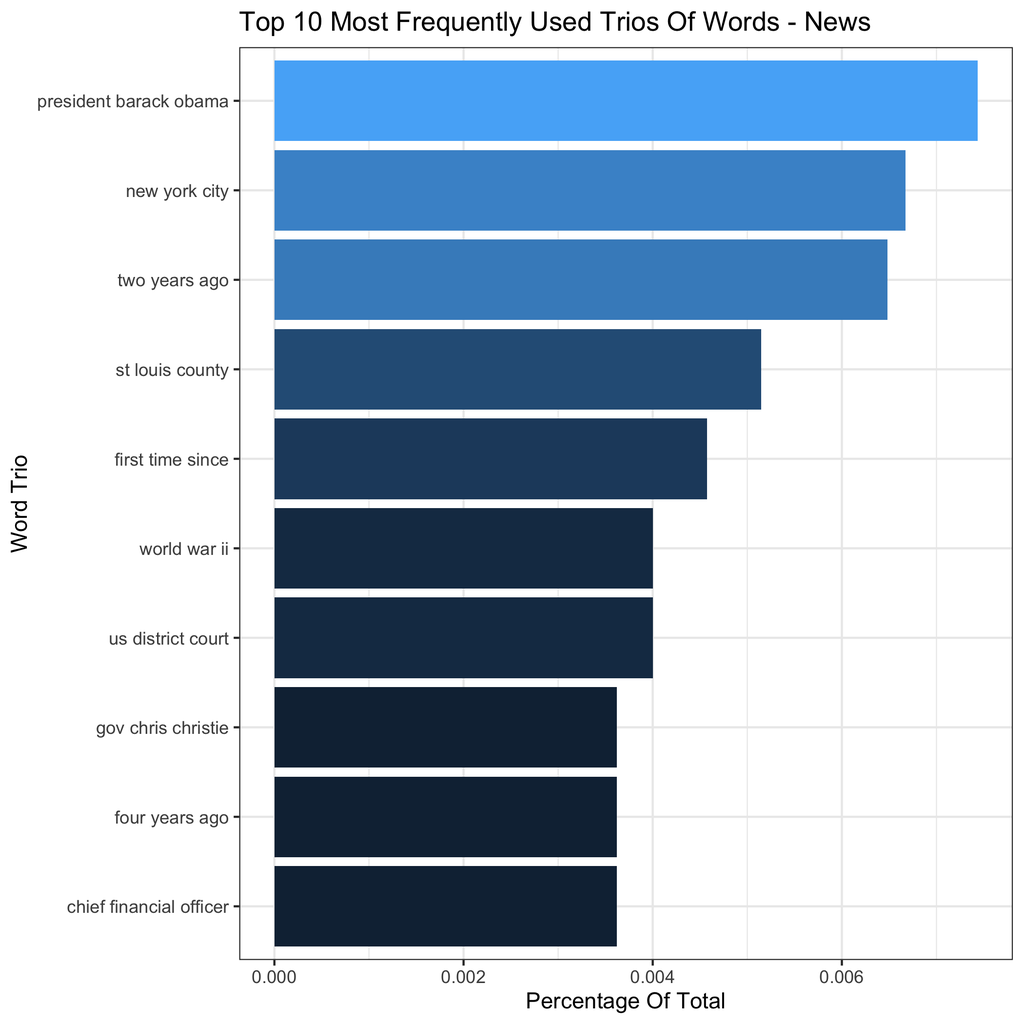

## TF-IDF Frequency Plots

Term frequency, inverse document frequency (TF-IDF) statistics measure how important a word is to a document or a collection of documents. TF-IDF’s are calculated by measuring the frequency of a word (term frequency) by its inverse document frequency, which decreases the weight for commonly used words and increases the weight for words that are not used often in a collection of documents.

### Example: TF-IDF Frequency Plot - News

The TF-IDF frequency plot for the news data set provides an interesting example of this. “Officer” isn’t a word that’s overly common in everyday conversation, but in the news - where crime is talked about far more often than in other contexts - it’s used regulary, leading to it having a high TF-IDF score.

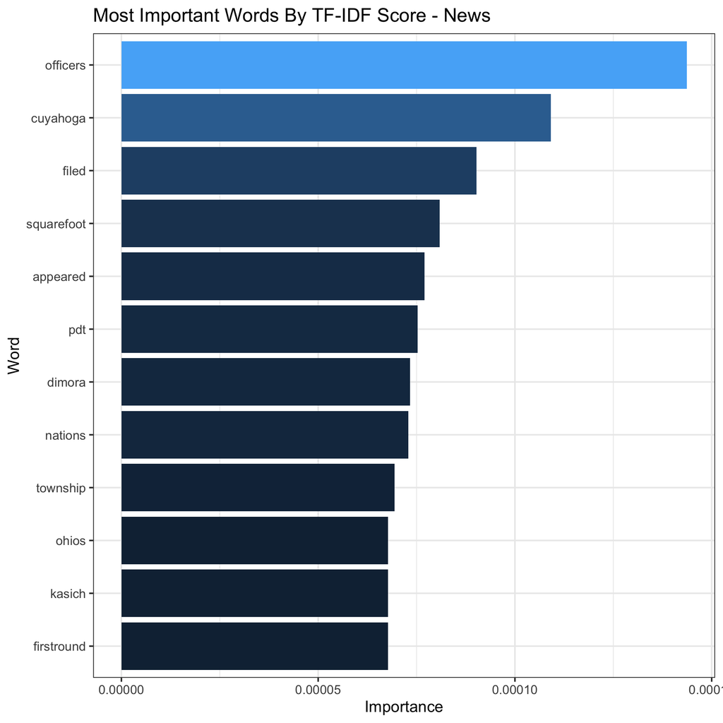

## Sentiment Analysis

To analyze the sentiment of a text, the sentiment of the entire text is defined as the sum of the sentiment content of each individual word.

There are several general-purpose lexicons that can be used to determine sentiment:

- `AFINN` assigns words a score between -5 and 5, with larger numbers being considered more positive.
- `bing` categorizes words as either “positive” or “negative”.
- `nrc` categorizes words as either “yes” or “no” for a variety of sentiments (ie. happiness, fear, etc.).

I use the `AFINN` lexicon to determine the average sentiment of each of the three data sources.

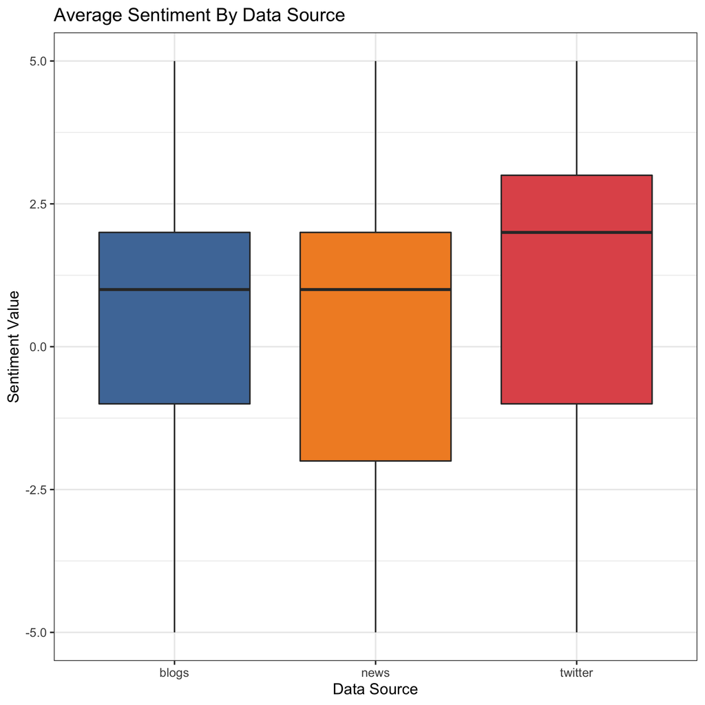

All three data sources have a generally positive sentiment. Blogs and news have a nearly identical average sentiment, although the news has more variance in sentiment. On average, twitter is the most positive of the three data sources.

This is an interesting result, because I tend to think of the news as a generally negative source of information - I would’ve expected its average sentiment to be lower.

# SBO Prediction Model

## Overview

SBO’s are referred to as “stupid” because of their relatively simple algorithm, but this doesn’t mean they’re an ineffective predictor of the next word in a sentence. SBO’s work as follows:

- When trying to predict which word will appear next in a sentence, it will first look for the context of the word at the n-gram level (in my case, 5-gram level). If there is no 5-gram of that size, it will recurse to the (n-1)-gram and multiply its score by 0.4. The recursion ends once the model reaches unigrams.
- For example, if I wanted to determine the probability of “you” in the sentence “Hi there, how are you?”, the model would first see if the 5-gram “Hi there, how are you?” exists. If it didn’t, the model would drop the most distant word and try again with the 4-gram “there, how are you?”, multiplying its score by 0.4 (aka penalizing it). If it still didn’t exist, it would then move to the trigram level, penalizing the score once again, and so on and so forth.

# Next Steps

The end goal here is to build a predictive algorithm and deploy it as a Shiny app, where the app will take a phrase as input and output its prediction of the next word.

While I could accomplish this with the SBO model detailed above, I’d love to use some more advanced natural language processing such as Long Short Term Memory (LSTM). Unfortunately, the `keras` and `tensorflow` packages are primarily built for Python - and while there are wrappers to make them work in R, I’ve been unable to use them without my ten-year old Mac’s keyboard getting hotter than the surface of the sun.

In the coming weeks, I’ll be looking into LSTM and other Recurrent Neural Network (RNN) techniques to determine if any of them will be feasible given my laptops computational constraints.

# Appendix

The appendix below displays the code I’ve written to process, explore, and model the data.

## 01 - dataProcessing.R

```r
###################
# Data Processing #
###################

## This script takes the first 30k lines from each of the three data sources
## and tokenizes them using the "tm" and "tidytext" packages.

## Load packages
library(tidyverse)
library(tm)
library(tidytext)
library(stopwords)
library(quanteda)
library(rsample)

## Set working directory
setwd("/Users/kevinroche22/RData/SwiftkeyTextMiningAndAnalytics/rawData")

## List of file names
fileNames <- list.files(getwd())

## Read in raw data, capping the number of lines at 30k (huge files - this sample size should suffice)
rawTextData <- fileNames %>% map_dfc(function(file) {

        ## Applies readLines functions to each of the three files
        readr::read_lines(file, skip = 3, n_max = 30000)

})

## Name data
names(rawTextData) <- c("blogs", "news", "twitter")

## Write to dataSamples folder
write_csv(rawTextData, "/Users/kevinroche22/RData/SwiftkeyTextMiningAndAnalytics/dataSamples/rawDataSample.csv")

################
# Data for EDA #
################

## Format and clean using tm, stopwords and tidytext
tidyTextData <- unique(names(rawTextData)) %>% map_dfr(function(name) {

        ## Progress check
        print(name)

        ## Format and build out word groupings
        VCorpus(VectorSource(rawTextData[[name]])) %>% # Change to corpus format
                tm_map(removeNumbers) %>% # Remove numbers
                tm_map(removePunctuation) %>% # Remove punctuation
                tm_map(stripWhitespace) %>% # Strip whitespace
                tm_map(content_transformer(tolower)) %>% # Make lowercase
                tidy() %>% # tidy returns a tbl_df with one-row-per-document
                unnest_tokens(word, text) %>% # Splits text column into word tokens, flattening the table into one-token-per-row
                anti_join(get_stopwords(source = "snowball"), by = "word") %>%
                group_by(id) %>% # otherwise we'd get word strings across sentences
                mutate(stem = SnowballC::wordStem(word),
                       bigram = paste(lag(word), word, sep = " "),
                       trigram = paste(lag(word), word, lead(word), sep = " "),
                       fourgram = paste(lag(word, n = 2), lag(word), word, lead(word), sep = " "),
                       fivegram = paste(lag(word, n = 2), lag(word), word, lead(word), lead(word, n = 2), sep = " "),
                       dataset = name) %>% # identifier for which dataset text came from
                ungroup()

})

## Replace word groupings that aren't full with NA - faster using base R than piping into the mapping above
is.na(tidyTextData$bigram) <- str_detect(tidyTextData$bigram, "NA")
is.na(tidyTextData$trigram) <- str_detect(tidyTextData$trigram, "NA")
is.na(tidyTextData$fourgram) <- str_detect(tidyTextData$fourgram, "NA")
is.na(tidyTextData$fivegram) <- str_detect(tidyTextData$fivegram, "NA")

######################
# Data for SBO Model #
######################

## Pivot data longer
rawTextData <- rawTextData %>%
        pivot_longer(everything(), values_to = "text") %>%
        select(text)

## Split into training and testing
splitRawTextData <- rawTextData %>%
        initial_split(prop = 0.8)

trainData <- training(splitRawTextData)
testData <- testing(splitRawTextData)

## Convert to corpus
tidyTrainData <- trainData$text %>%
        corpus()

tidyTestData <- testData$text %>%
        corpus()

#####################################
## Write results to tidyData folder #
#####################################

write_rds(tidyTextData, "/Users/kevinroche22/RData/SwiftkeyTextMiningAndAnalytics/tidyData/tidyData.rds")
write_rds(tidyTrainData, "/Users/kevinroche22/RData/SwiftkeyTextMiningAndAnalytics/tidyData/tidyTrainData.rds")
write_rds(tidyTestData, "/Users/kevinroche22/RData/SwiftkeyTextMiningAndAnalytics/tidyData/tidyTestData.rds")
```

## 02 - exploratoryDataAnalysis

```r
#############################
# Exploratory Data Analysis #
#############################

## In this section we compute and plot the top 10 most common single words,
## word pairs, word trios, word quartets, and word quintets, and then plot
## their associated word clouds. We also create summary stats, build tf-idf
## plots and perform sentiment analysis.

## Load packages
library(tidyverse)
library(ggplot2)
library(ggthemes)
library(wordcloud2)
library(tidytext)

## Set working directory
setwd("/Users/kevinroche22/RData/SwiftkeyTextMiningAndAnalytics/EDACharts/")

## List of file names for tidy data
tidyDataFolder <- "/Users/kevinroche22/RData/SwiftkeyTextMiningAndAnalytics/tidyData/"

## Read in tidy data
tidyTextData <- read_rds(file = paste0(tidyDataFolder, "tidyData.rds"))

## List of file names for raw data
rawDataFileNames <- paste0("/Users/kevinroche22/RData/SwiftkeyTextMiningAndAnalytics/rawData/",
                           list.files("/Users/kevinroche22/RData/SwiftkeyTextMiningAndAnalytics/rawData/"))

## Read in raw data
rawTextData <- rawDataFileNames %>% map_dfc(function(file) {

        ## Applies readLines functions to each of the three files
        readr::read_lines(file, skip = 3, n_max = 30000)

})

## Name raw data
names(rawTextData) <- c("blogs", "news", "twitter")

#################
# Summary Stats #
#################

## Calculate file size
fileSizes <- rawDataFileNames %>% map_dfc(function(file) {

        ## Return file size
        paste0(round(file.size(file) / 1000000, 2), " mb")

})

## Summarize raw data
rawDataSummary <- rawDataFileNames %>% map_dfr(function(file) {

        ## Applies readLines functions to each of the three files
        rawFile <- readLines(file)

        ## Return stats
        stringi::stri_stats_general(rawFile)

})

## Add descriptive column and reorder
rawDataSummary <- rawDataSummary %>%
        mutate(file = c("blogs", "news", "twitter")) %>%
        bind_cols(fileSize = t(fileSizes)) %>%
        relocate(file) %>%
        select(-c("LinesNEmpty", "CharsNWhite")) %>% # Not particularly useful information imo
        as.matrix() %>%
        as.data.frame() # Has to be in df format to write but first needed to convert to matrix due to transpose

## Name columns
names(rawDataSummary) <- c("file", "numberOfLines", "numberOfCharacters", "fileSize")

## Write to folder
write_csv(rawDataSummary, "/Users/kevinroche22/RData/SwiftkeyTextMiningAndAnalytics/dataSamples/summaryStats.csv")

############
# Unigrams #
############

## Plot top 10 most commonly used words (%) from each source
unigramFreqPlots <- unique(tidyTextData$dataset) %>% map(function(name) {

        ## Progress check
        print(name)

        ## Build plot
        tidyTextData %>%
                filter(dataset == name) %>%
                count(word) %>%
                mutate(percent = 100*(n/sum(n))) %>%
                slice(-n) %>%
                slice_max(percent, n = 10) %>%
                ggplot(aes(x = reorder(word, percent), y = percent, fill = percent)) +
                geom_bar(stat = "identity") +
                coord_flip() +
                ggtitle(paste0("Top 10 Most Frequently Used Words - ", tools::toTitleCase(name))) +
                labs(x = "Word", y = "Percentage Of Total") +
                theme_bw() +
                scale_color_tableau() +
                theme(legend.position = "none")

})

## Name frequency plots
names(unigramFreqPlots) <- c("blogs", "news", "twitter")

## Write to EDA folder
pwalk(list(filename = paste0("frequencyPlots/unigram/Top10FrequencyWords - ", names(unigramFreqPlots), ".png"),
           plot = unigramFreqPlots),
      ggsave)

## Plot word clouds from each source and write to folder
unigramWordClouds <- unique(tidyTextData$dataset) %>% map(function(name) {

        ## Progress check
        print(name)

        ## Manipulate data
        countWords <- tidyTextData %>%
                filter(dataset == name) %>%
                count(word) %>%
                filter(n >= 3) %>%
                slice_max(n, n = 100)

        ## Build plot
        wordcloud2(data = countWords,
                   size = 1,
                   backgroundColor = "black",
                   shape = "circle")

})

## Name wordclouds
names(unigramWordClouds) <- c("blogs", "news", "twitter")

## Write to folder
unique(names(unigramWordClouds)) %>% map(function(name) {

        ## Progress check
        print(name)

        htmlwidgets::saveWidget(unigramWordClouds[[name]],
                                paste0("wordClouds/unigram/unigramWordClouds - ", name, ".html"), selfcontained = F)
        webshot::webshot(paste0("wordClouds/unigram/unigramWordClouds - ", name, ".html"),
                         paste0("wordClouds/unigram/unigramWordClouds - ", name, ".png"),
                         vwidth = 600,
                         vheight = 600,
                         delay = 10)

})

###########
# Bigrams #
###########

## Plot top 10 most commonly used pairs of words (%) from each source
bigramFreqPlots <- unique(tidyTextData$dataset) %>% map(function(name) {

        ## Progress check
        print(name)

        ## Build plot
        tidyTextData %>%
                filter(dataset == name,
                       !(is.na(bigram))) %>%
                count(bigram) %>%
                mutate(percent = 100*(n/sum(n))) %>%
                slice(-n) %>%
                slice_max(percent, n = 10) %>%
                ggplot(aes(x = reorder(bigram, percent), y = percent, fill = percent)) +
                geom_bar(stat = "identity") +
                coord_flip() +
                ggtitle(paste0("Top 10 Most Frequently Used Bigrams - ", tools::toTitleCase(name))) +
                labs(x = "Bigram", y = "Percentage Of Total") +
                theme_bw() +
                scale_color_tableau() +
                theme(legend.position = "none")

})

## Name frequency plots
names(bigramFreqPlots) <- c("blogs", "news", "twitter")

## Write to EDA folder
pwalk(list(filename = paste0("frequencyPlots/bigram/Top10FrequencyPairs - ", names(bigramFreqPlots), ".png"),
           plot = bigramFreqPlots),
      ggsave)
```

```r
## Plot word clouds from each source
bigramWordClouds <- unique(tidyTextData$dataset) %>% map(function(name) {

        ## Progress check
        print(name)

        ## Manipulate data
        countWords <- tidyTextData %>%
                filter(dataset == name,
                       !(is.na(bigram))) %>%
                count(bigram) %>%
                filter(n >= 3) %>%
                slice_max(n, n = 100)

        ## Build plot
        wordcloud2(data = countWords,
                   size = 1,
                   backgroundColor = "black",
                   shape = "circle")

})

## Name wordclouds
names(bigramWordClouds) <- c("blogs", "news", "twitter")

## Write to folder
unique(names(bigramWordClouds)) %>% map(function(name) {

        ## Progress check
        print(name)

        htmlwidgets::saveWidget(bigramWordClouds[[name]],
                                paste0("wordClouds/bigram/bigramWordClouds - ", name, ".html"), selfcontained = F)
        webshot::webshot(paste0("wordClouds/bigram/bigramWordClouds - ", name, ".html"),
                         paste0("wordClouds/bigram/bigramWordClouds - ", name, ".png"),
                         vwidth = 600,
                         vheight = 600,
                         delay = 10)

})

###########
# 3-grams #
###########

## Plot top 10 most commonly used trios of words (%) from each source
trigramFreqPlots <- unique(tidyTextData$dataset) %>% map(function(name) {

        ## Progress check
        print(name)

        ## Build plot
        tidyTextData %>%
                filter(dataset == name,
                       !(is.na(trigram))) %>%
                count(trigram) %>%
                mutate(percent = 100*(n/sum(n))) %>%
                slice(-n) %>%
                slice_max(percent, n = 10) %>%
                ggplot(aes(x = reorder(trigram, percent), y = percent, fill = percent)) +
                geom_bar(stat = "identity") +
                coord_flip() +
                ggtitle(paste0("Top 10 Most Frequently Used Trios Of Words - ", tools::toTitleCase(name))) +
                labs(x = "Word Trio", y = "Percentage Of Total") +
                theme_bw() +
                scale_color_tableau() +
                theme(legend.position = "none")

})

## Name frequency plots
names(trigramFreqPlots) <- c("blogs", "news", "twitter")

## Write to EDA folder
pwalk(list(filename = paste0("frequencyPlots/trigram/Top10FrequencyTrios - ", names(trigramFreqPlots), ".png"),
           plot = trigramFreqPlots),
      ggsave)

## Plot word clouds from each source
trigramWordClouds <- unique(tidyTextData$dataset) %>% map(function(name) {

        ## Progress check
        print(name)

        ## Manipulate data
        countWords <- tidyTextData %>%
                filter(dataset == name,
                       !(is.na(trigram))) %>%
                count(trigram) %>%
                filter(n >= 3) %>%
                slice_max(n, n = 100)

        ## Build plot
        wordcloud2(data = countWords,
                   size = 1,
                   backgroundColor = "black",
                   shape = "circle")

})

## Name wordclouds
names(trigramWordClouds) <- c("blogs", "news", "twitter")

## Write to folder
unique(names(trigramWordClouds)) %>% map(function(name) {

        ## Progress check
        print(name)

        htmlwidgets::saveWidget(trigramWordClouds[[name]],
                                paste0("wordClouds/trigram/trigramWordClouds - ", name, ".html"), selfcontained = F)
        webshot::webshot(paste0("wordClouds/trigram/trigramWordClouds - ", name, ".html"),
                         paste0("wordClouds/trigram/trigramWordClouds - ", name, ".png"),
                         vwidth = 600,
                         vheight = 600,
                         delay = 10)

})

###########
# 4-grams #
###########

## Plot top 10 most commonly used quartets of words (%) from each source
fourgramFreqPlots <- unique(tidyTextData$dataset) %>% map(function(name) {

        ## Progress check
        print(name)

        ## Build plot
        tidyTextData %>%
                filter(dataset == name,
                       !(is.na(fourgram))) %>%
                count(fourgram) %>%
                mutate(percent = 100*(n/sum(n))) %>%
                slice(-n) %>%
                slice_max(percent, n = 10) %>%
                ggplot(aes(x = reorder(fourgram, percent), y = percent, fill = percent)) +
                geom_bar(stat = "identity") +
                coord_flip() +
                ggtitle(paste0("Top 10 Most Frequently Used Quartets Of Words - ", tools::toTitleCase(name))) +
                labs(x = "Word Quartet", y = "Percentage Of Total") +
                theme_bw() +
                scale_color_tableau() +
                theme(legend.position = "none")

})

## Name frequency plots
names(fourgramFreqPlots) <- c("blogs", "news", "twitter")

## Write to EDA folder
pwalk(list(filename = paste0("frequencyPlots/fourgram/Top10FrequencyQuartets - ", names(fourgramFreqPlots), ".png"),
           plot = fourgramFreqPlots),
      ggsave)

## Plot word clouds from each source
fourgramWordClouds <- unique(tidyTextData$dataset) %>% map(function(name) {

        ## Progress check
        print(name)

        ## Manipulate data
        countWords <- tidyTextData %>%
                filter(dataset == name,
                       !(is.na(fourgram))) %>%
                count(fourgram) %>%
                filter(n >= 2) %>%
                slice_max(n, n = 100)

        ## Build plot
        wordcloud2(data = countWords,
                   size = 1,
                   backgroundColor = "black",
                   shape = "circle")

})

## Name wordcloud
names(fourgramWordClouds) <- c("blogs", "news", "twitter")

## Write to folder
unique(names(fourgramWordClouds)) %>% map(function(name) {

        ## Progress check
        print(name)

        htmlwidgets::saveWidget(fourgramWordClouds[[name]],
                                paste0("wordClouds/fourgram/fourgramWordClouds - ", name, ".html"), selfcontained = F)
        webshot::webshot(paste0("wordClouds/fourgram/fourgramWordClouds - ", name, ".html"),
                         paste0("wordClouds/fourgram/fourgramWordClouds - ", name, ".png"),
                         vwidth = 600,
                         vheight = 600,
                         delay = 10)
```

```r
})

###########
# 5-grams #
###########

## Plot top 10 most commonly used quintets of words (%) from each source
fivegramFreqPlots <- unique(tidyTextData$dataset) %>% map(function(name) {

        ## Progress check
        print(name)

        ## Build plot
        tidyTextData %>%
                filter(dataset == name,
                       !(is.na(fivegram))) %>%
                count(fivegram) %>%
                mutate(percent = 100*(n/sum(n))) %>%
                slice(-n) %>%
                slice_max(percent, n = 10) %>%
                ggplot(aes(x = reorder(fivegram, percent), y = percent, fill = percent)) +
                geom_bar(stat = "identity") +
                coord_flip() +
                ggtitle(paste0("Top 10 Most Frequently Used Quintets Of Words - ", tools::toTitleCase(name))) +
                labs(x = "Word Quintet", y = "Percentage Of Total") +
                theme_bw() +
                scale_color_tableau() +
                theme(legend.position = "none")

})

## Name frequency plots
names(fivegramFreqPlots) <- c("blogs", "news", "twitter")

## Write to EDA folder
pwalk(list(filename = paste0("frequencyPlots/fivegram/Top10FrequencyQuintets - ", names(fivegramFreqPlots), ".png"),
           plot = fivegramFreqPlots),
      ggsave)

## Plot word clouds from each source
fivegramWordClouds <- unique(tidyTextData$dataset) %>% map(function(name) {

        ## Progress check
        print(name)

        ## Manipulate data
        countWords <- tidyTextData %>%
                filter(dataset == name,
                       !(is.na(fivegram))) %>%
                count(fivegram) %>%
                filter(n >= 2) %>%
                slice_max(n, n = 100)

        ## Build plot
        wordcloud2(data = countWords,
                   size = 1,
                   backgroundColor = "black",
                   shape = "circle")

})

## Name wordcloud
names(fivegramWordClouds) <- c("blogs", "news", "twitter")

## Write to folder
unique(names(fivegramWordClouds)) %>% map(function(name) {

        ## Progress check
        print(name)

        htmlwidgets::saveWidget(fivegramWordClouds[[name]],
                                paste0("wordClouds/fivegram/fivegramWordClouds - ", name, ".html"), selfcontained = F)
        webshot::webshot(paste0("wordClouds/fivegram/fivegramWordClouds - ", name, ".html"),
                         paste0("wordClouds/fivegram/fivegramWordClouds - ", name, ".png"),
                         vwidth = 600,
                         vheight = 600,
                         delay = 10)

})

######################
# Sentiment Analysis #
######################

## Plot average sentiment scores by data source and write to sentiment analysis folder
(tidyTextData %>%
        inner_join(get_sentiments("afinn"), by = c("word" = "word")) %>%
        group_by(dataset) %>%
        ggplot(aes(x = dataset, y = value, fill = dataset)) +
        geom_boxplot() +
        ggtitle("Average Sentiment By Data Source") +
        labs(x = "Data Source", y = "Sentiment Value") +
        theme_bw() +
        scale_fill_tableau() +
        theme(legend.position = "none")) %>%
        ggsave(file = paste0(getwd(), "/sentimentAnalysis/sentimentAnalysis.png"))

################
# TF-IDF Plots #
################

## TF-IDF scores account for how common a word is to determine which words
## are most important (ie. more common than is typical) to a text

## Plot 10 words with highest TF-IDF score
tfidfPlots <- unique(tidyTextData$dataset) %>% map(function(name) {

        ## Check Progress
        print(name)

        ## Build plot
        tidyTextData %>%
                group_by(dataset) %>%
                count(word) %>%
                bind_tf_idf(word, dataset, n) %>%
                filter(dataset == name,
                       n >= 30) %>%
                slice_max(tf_idf, n = 10) %>%
                ggplot(aes(x = reorder(word, tf_idf), y = tf_idf, fill = tf_idf)) +
                geom_bar(stat = "identity") +
                coord_flip() +
                ggtitle(paste0("Most Important Words By TF-IDF Score - ", tools::toTitleCase(name))) +
                labs(x = "Word", y = "Importance") +
                theme_bw() +
                scale_color_tableau() +
                theme(legend.position = "none")

})

## Name TF-IDF Plots
names(tfidfPlots) <- c("blogs", "news", "twitter")

## Write to EDA folder
pwalk(list(filename = paste0("tfidfPlots/TF-IDF Plot - ", names(tfidfPlots), ".png"),
           plot = tfidfPlots),
      ggsave)
```

## 03 - dataModeling.R

```r
#################
# Data Modeling #
#################

## In this section we build a stupid backoff model (sbo) to predict the
## next word based on the previous n-grams (in this case, I use 5)

## Load packages
library(tidyverse)
library(tidymodels)
library(textrecipes)
library(tensorflow)
library(keras)
library(sbo)

## Set working directory
setwd("/Users/kevinroche22/RData/SwiftkeyTextMiningAndAnalytics/models/")

## List of file names
tidyDataFolder <- "/Users/kevinroche22/RData/SwiftkeyTextMiningAndAnalytics/tidyData/"

## Read in tidy data
trainData <- read_rds(file = paste0(tidyDataFolder, "tidyTrainData.rds"))
testData <- read_rds(file = paste0(tidyDataFolder, "tidyTestData.rds"))

###############################
# Stupid Back Off (SBO) Model #
###############################

## Set seed
set.seed(824) # ripKobe

## Build predictor
sboPredictor <- sbo_predictor(object = trainData, # training data
                                            N = 5, # 5-gram model
                                            dict = target ~ 0.75, # 75% of training corpus used in dictionary
                                            .preprocess = sbo::preprocess, # removes anything non alphanumeric, whitespace, converts to lower, etc.
                                            EOS = ".?!:;", # End-Of-Sentence tokens
                                            lambda = 0.4, # Back-off penalization in SBO algorithm - parameter suggested by authors of methodology
                                            L = 3L, # Number of predictions
                                            filtered = c("<UNK>", "<EOS>") # Exclude the <UNK> and <EOS> tokens from predictions
)

## Evaluate Predictions
sboEvaluation <- eval_sbo_predictor(sboPredictor, test = testData)

## Determine accuracy - ~18%
sboEvaluation %>%
        filter(true != "<EOS>") %>%
        summarise(accuracyPercentage = (sum(correct)/n())*100,
                  accuracy = sum(correct)/n(),
                  uncertaintyPercentage = sqrt(accuracy * (1 - accuracy) / n()))

## Stores next word probability in order of score
sboKGrams <- kgram_freqs(trainData,
                         N = 5,
                         dict = target ~ 0.75,
                         .preprocess = sbo::preprocess,
                         EOS = ".?!:;")

## Example - predict top 3 words after typing
predict(sboPredictor, "Thanks for having us, we had a great time with")

## Example - all words in dictionary arranged by probability
predict(sboKGrams, "Thanks for having us, we had a great time with")
```